# emileygz_OriginalHomeworkCode_04

Emiley Garcia-Zych

2023-10-30

```r
library(ggplot2) #load the necessary packages
library(curl)
```

# Homework 4: What’s Your Malfunction?

## Emiley Garcia-Zych

1. Write a simple R function, Z.prop.test(), that can perform one- or two- sample Z tests for proportion data, using the following guidelines.

```r
Z.prop.test <- function(p1, n1, p2 = NULL, n2 = NULL, p0, alternative = "two.sided", conf.level = 0.95) { # defines a new fucntion "Z.prop.test()" that takes the arguments "p1" and "p2", sample sizes "n1" and "n2", null hypothesis proportion "p0", the type of test, and confidence level of 95%. If p2 and n2 are not provided, the test will be able to run a one-sample test.

  one_sample_test <- is.null(p2) || is.null(n2) # Checks if either p2 or n2 is NULL to determine one-sample or two-sample test

  # Calculate the estimated proportion in a two-sample case
  if (one_sample_test) {
    p1_hat <- p1
  }
  else {
    p1_hat <- p1
    p2_hat <- p2
  }

  # Check rules of thumb
  if (n1 * p1_hat > 5 && n1 * (1 - p1_hat) > 5 && (one_sample_test || (n2 * p2_hat > 5 && n2 * (1 - p2_hat) > 5))) { ##makes sure both samples are large enough to run the tests.
    standard_error <- sqrt(p1_hat * (1 - p1_hat) / n1) # Calculate the standard error

    if (!one_sample_test) { #checks to see if it is a two-sample test. If it is a one-sample test, it continues to the else...
      standard_error2 <- sqrt(p2_hat * (1 - p2_hat) / n2)
      pooled_standard_error <- sqrt((standard_error^2 / n1) + (standard_error2^2 / n2))
      Z_score <- (p1_hat - p2_hat) / pooled_standard_error ##calculates Z statistic
    }
    else {
      Z_score <- (p1_hat - p0) / standard_error
    }

    if (alternative == "greater") {
      P <- 1 - pnorm(Z)
    } else if (alternative == "less") {
      P <- pnorm(Z)
    } else {
      P <- 2 * (1 - pnorm(abs(Z)))
    }

    # Calculate the confidence interval
    alpha <- 1 - conf.level
    if (one_sample_test) {
      margin_of_error <- qnorm(1 - alpha / 2) * standard_error
      CI <- c(p1_hat - margin_of_error, p1_hat + margin_of_error)
    } else {
      margin_of_error <- qnorm(1 - alpha / 2) * pooled_standard_error
      CI <- c(p1_hat - p2_hat - margin_of_error, p1_hat - p2_hat + margin_of_error)
    }

    result <- list(Z = Z, P = P, CI = CI)
    return(result)
  } else { ##returns a warning and lets the user know there was some issue with the data.
    warning("The rules of thumb (n*p > 5 and n*(1-p) > 5) are violated. The results may not be valid.")
    return(NULL)
  }
}
```

2. The dataset from Kamilar and Cooper has in it a large number of variables related to life history and body size. For this exercise, the end aim is to fit a simple linear regression model to predict longevity (MaxLongevity_m) measured in months from species’ brain size (Brain_Size_Species_Mean) measured in grams. Do the following for both longevity~brain size and log(longevity)~log(brain size):

```r
k_and_c <- curl("https://raw.githubusercontent.com/fuzzyatelin/fuzzyatelin.github.io/master/AN588_Fall23/KamilarAndCooperData.csv")
d <- read.csv(k_and_c, header = TRUE, stringsAsFactors = FALSE)
d
```

[output not shown]

[output cut: 2767 more lines]

**Jess’s comment: Consider using the head () function. Thus, you will only be displaying the first n rows present in the input data frame and not everything.**

```r
is.atomic(d) ## I was having trouble and kept running into the atomic value error.
```

```
## [1] FALSE
```

**Jess’s comment: I’m not familiar with the ‘is.atomic’ function in R. After a quick Google search the output of ‘FALSE’ refers to that the object has attributes other than its mode, such as names or dimensions, making it non-atomic. I’m not sure if this function should be used in this context.**

```r
getElement(d, 'MaxLongevity_m')
```

[output not shown]

**Jess’s comment: Cool! I have also never used the ‘getElement’ function before. Consider assigning the variables (e.g., MaxLongevity_m) to objects so you do not have to recall them from the dataset later. EX: l <- d$MaxLongevity_m**

1. Fit the regression model and, using {ggplot2}, produce a scatterplot with the fitted line superimposed upon the data. Append the the fitted model equation to your plot (HINT: use the function geom_text()).

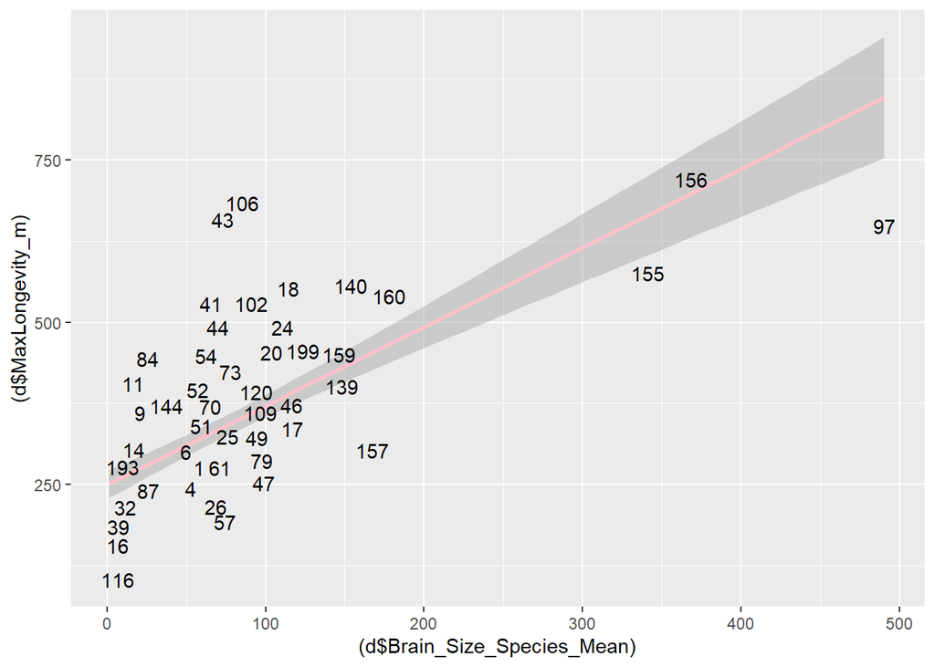

```r
library(ggplot2)

# Fit longevity~brain size model
model1 <- lm(d$MaxLongevity_m ~ d$Brain_Size_Species_Mean, data = d)

plot1 <- ggplot(d, aes((d$Brain_Size_Species_Mean), (d$MaxLongevity_m), label = rownames(d))) + geom_smooth(method = "lm", formula = y ~ x, color = "pink")
plot1 + geom_text(check_overlap = TRUE)
```

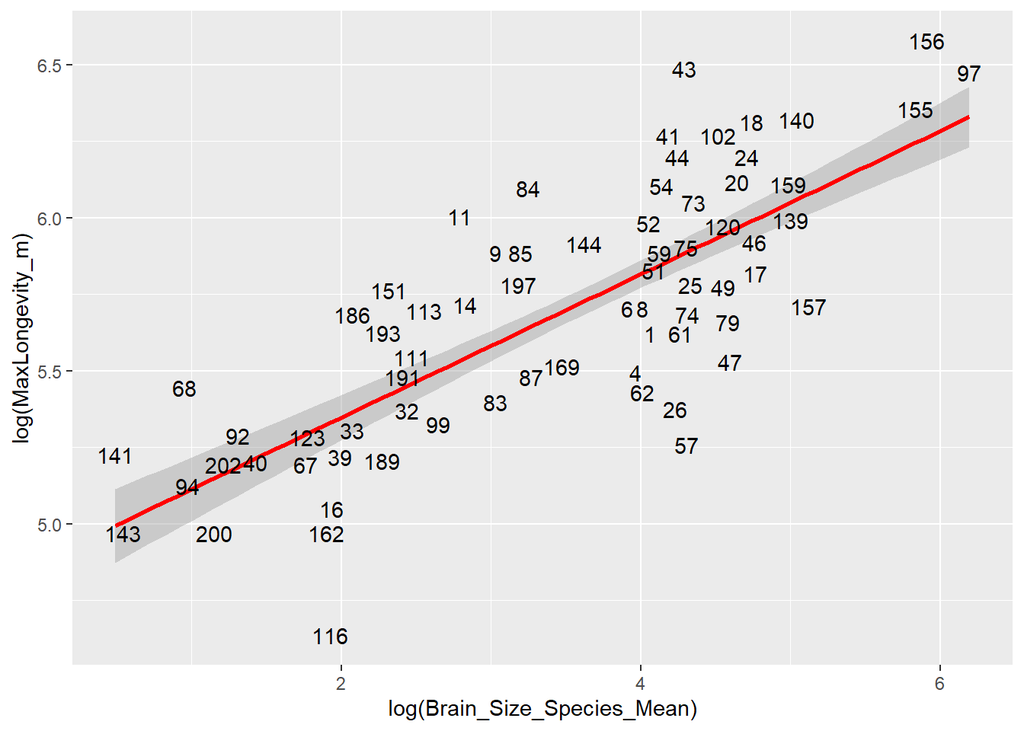

```r
# Fit log(longevity)~log(brain size) model
model2 <- lm(log(d$MaxLongevity_m) ~ log(d$Brain_Size_Species_Mean), data = d)

plot2 <- ggplot(d, aes(log(Brain_Size_Species_Mean), log(MaxLongevity_m), label = rownames(d)))+ geom_smooth(method = "lm", formula = y ~ x, color = "red")

plot2 + geom_text(check_overlap = TRUE)
```

2. Identify and interpret the point estimate of the slope (β1), as well as the outcome of the test associated with the hypotheses H0: β1 = 0; HA: β1 ≠ 0. Also, find a 90 percent CI for the slope (β1) parameter.

```r
# Assuming you have fitted a linear regression model, e.g., model1

# Point estimate of the slope (β1)
slope_estimate <- coef(model1)["Brain_Size_Species_Mean"]

# Conduct the hypothesis test and find the p-value
p_value <- summary(model1)$coefficient["Brain_Size_Species_Mean"]

# 90% confidence interval for the slope (β1)
conf_interval <- confint(model1, level = 0.90)["Brain_Size_Species_Mean"]

# Interpretation
##cat("Point estimate of the slope (β1):", slope_estimate, "\n")
##cat("Hypothesis test (β1 ≠ 0):\n")
##cat("   - p-value:", p_value, "\n")
##if (p_value < 0.05) {
##  cat("   - Interpretation: We reject the null hypothesis (β1 = 0) at the 0.05 significance level.\n")
##} else {
##  cat("   - Interpretation: We do not have sufficient evidence to reject the null hypothesis (β1 = 0) at the 0.05 significance level.\n")
##}
##cat("90% Confidence Interval for the slope (β1): [", conf_interval[1], ",", conf_interval[2], "]\n")
```

**Jess’s comment: I’m not exactly sure what is happening here. I think separating your code into different chunks with more detailed annotations would be extremely beneficial.**

```r
summary(model1)
```

```
##
## Call:
## lm(formula = d$MaxLongevity_m ~ d$Brain_Size_Species_Mean, data = d)
##
## Residuals:
##     Min      1Q  Median      3Q     Max
## -198.27  -61.92  -17.78   56.16  331.36
##
## Coefficients:
##                           Estimate Std. Error t value Pr(>|t|)
## (Intercept)               248.9523    11.1111   22.41   <2e-16 ***
## d$Brain_Size_Species_Mean   1.2180     0.1101   11.06   <2e-16 ***
## ---
## Signif. codes:  0 '***' 0.001 '**' 0.01 '*' 0.05 '.' 0.1 ' ' 1
##
## Residual standard error: 90.91 on 126 degrees of freedom
##   (85 observations deleted due to missingness)
## Multiple R-squared:  0.4928, Adjusted R-squared:  0.4887
## F-statistic: 122.4 on 1 and 126 DF,  p-value: < 2.2e-16
```

```r
summary(model2)
```

```
##
## Call:
## lm(formula = log(d$MaxLongevity_m) ~ log(d$Brain_Size_Species_Mean),
##     data = d)
##
## Residuals:
##     Min      1Q  Median      3Q     Max
## -0.6955 -0.1750 -0.0097  0.1788  0.6084
##
## Coefficients:
##                                Estimate Std. Error t value Pr(>|t|)
## (Intercept)                     4.87895    0.06907   70.63   <2e-16 ***
## log(d$Brain_Size_Species_Mean)  0.23415    0.01781   13.15   <2e-16 ***
## ---
## Signif. codes:  0 '***' 0.001 '**' 0.01 '*' 0.05 '.' 0.1 ' ' 1
##
## Residual standard error: 0.2485 on 126 degrees of freedom
##   (85 observations deleted due to missingness)
## Multiple R-squared:  0.5784, Adjusted R-squared:  0.5751
## F-statistic: 172.9 on 1 and 126 DF,  p-value: < 2.2e-16
```

```r
confint(model1, level = 0.9)
```

```
##                                  5 %      95 %
## (Intercept)               230.540738 267.36379
## d$Brain_Size_Species_Mean   1.035571   1.40041
```

```r
confint(model2, level = 0.9)
```

```
##                                      5 %      95 %
## (Intercept)                    4.7644934 4.9934084
## log(d$Brain_Size_Species_Mean) 0.2046396 0.2636595
```

**Jess’s comment: Perfect! I did the same thing! Albeit, we did get different results.**

```r
# Predict longevity for species with brain weight of 800 gm using the first model
new_data <- data.frame(Brain_Size_Species_Mean = 800)
predicted_longevity <- predict(model1, newdata = new_data)
# 90% prediction interval
pi <- predict(model1, newdata = new_data, interval = "prediction", level = 0.9)
print("Predicted Longevity:")
```

```
## [1] "Predicted Longevity:"
```

```r
print(predicted_longevity)
```

[output not shown]

```r
print("90% Prediction Interval:")
```

```
## [1] "90% Prediction Interval:"
```

```r
print(pi)
```

[output not shown]

[output cut: 199 more lines]

**Jess’s comment: This is quite similar to what I did in terms of code, except in two different chunks! However, our results are different. Don’t forget to do this for log(brain size).**

**Jess’s comment: Good work! This was a very difficult homework assignment. As far as Question #2 goes, here is the steps I followed for both models (note: I’m not sure if this is correct):**

- Calculate the regression- beta 1 and beta 0 using the lm() function.
- Use the confint function to calculate the 90% confidence interval for the slope parameter, utilizing the lm() function.
- Create the regression equation using the paste() function, which will be incorporated into the ggplot.
- Generate a scatterplot with the fitted line superimposed.
- Calculate and incorporate lines for the 90% confidence interval and prediction interval bands into the plot.
- Use the predict() function to calculate the 90% prediction intervals, considering the same dataset used for the regression.
- Create a new data frame that includes the calculated confidence interval and prediction interval values.
- Develop another plot, add in lines for the 90 percent confidence and prediction interval bands, and add a legend to differentiate between the lines.
- Produce a point estimate and the associated 90% prediction interval for the longevity of a species with a brain weight of 800 gm.
- Answer the questions pertaining to each model.